# Memoria Fundamentos de Analisis de Datos.

Carlos Grande Nuñez, Veronica Gomez Gomez y Pablo Olmos Martinez

11/29/2019

## 00 Introducción a la práctica y librerías

Para la práctica hemos seleccionado una base de datos obtenida de Kaggle con los precios de viviendas del barrio King County en el estado de Washington (EEUU). Esta base de datos es de dominio público y consta de 21 variables con 21.613 observaciones.

La base de datos puede descargarse en el siguiente enlace: https://www.kaggle.com/swathiachath/kc-housesales-data

Las librerias usadas para esta práctica son las siguientes:

- Amelia
- brew
- bsplus
- DMwR2
- car
- carData
- caret
- cluster
- dplyr
- egg
- expss
- faraway
- gclus
- GGally
- ggplot2
- gridExtra
- Hmisc
- htmltools
- ISLR
- kableExtra
- knitr
- lattice
- magrittr
- mice
- mlbench
- RColorBrewer
- readr
- sos
- tidyr
- VIM

## 01 Definición de objetivos

1. Separación de los datos en 3 grupos de datos: trainning, control y testing.
   - El grupo training contiene el 70% de los datos, con el cual entrenaremos el modelo.
   - El grupo control contiene el 20% de los datos, el cual nos servirá para comprobar y ajustar el buen funcionamiento del modelo.
   - El grupo test contiene el 10% de los datos y se dejará como conjunto aislado hasta el final de la práctica como simulación de datos reales.
2. Analisis exploratorio inicial
   - Se llevará a cabo separando las variables categóricas de las cualitativas para su posterior estudio.

## 02 Carga y aislamiento de datos TEST

```r
relPath <- getwd()
setwd(relPath)
price_tplusc <- read.csv(file="./kc_house_data_missing.csv", sep = ";", header=TRUE, na = c("", "NA"), )
head(price_tplusc)
```

```
##           id       date   price bedrooms bathrooms sqft_living sqft_lot floors waterfront view condition
## 1 7129300520 10/13/2014  221900        3      1.00        1180     5650      1          0    0         3
## 2 6414100192 12/09/2014  538000        3      2.25        2570     7242      2          0    0         3
## 3 5631500400  2/25/2015  180000        2      1.00         770    10000      1          0    0         3
## 4 2487200875 12/09/2014  604000        4      3.00          NA     5000      1          0    0         5
## 5 1954400510  2/18/2015  510000        3      2.00        1680     8080      1         NA    0         3
## 6 7237550310 05/12/2014 1230000        4      4.50        5420   101930      1          0    0         3
##   grade sqft_above sqft_basement yr_built yr_renovated zipcode     lat     long sqft_living15 sqft_lot15
## 1     7       1180             0     1955            0   98178 475.112 -122.257          1340       5650
## 2     7       2170           400     1951         1991   98125  47.721 -122.319          1690       7639
## 3     6        770             0     1933            0   98028 477.379 -122.233          2720       8062
## 4     7       1050           910     1965            0   98136 475.208 -122.393          1360       5000
## 5     8       1680             0     1987            0   98074 476.168 -122.045          1800       7503
## 6    11       3890          1530     2001            0   98053 476.561 -122.005          4760     101930
```

Como ya hemos mencionado anteriormente, en este apartado excluimos de la base de datos el grupo TESTING (10% de los datos) para seguir trabajando con los grupos TRAINING + CONTROL a lo largo de la práctica.

- Training + control: “price_tplusc” (90% de observaciones)
- Testing: “price_testing” (10% de observaciones)

```r
set.seed(737)
inTraining     <- createDataPartition(pull(price_tplusc), p = .9, list = FALSE, times = 1)
price_tplusc   <- slice(price_tplusc, inTraining)
price_testing  <- slice(price_tplusc, -inTraining)
```

Finalmente obtenemos los siguientes grupos de observaciones

| Nombre del grupo | observaciones |
| --- | --- |
| Grupo TRAINING + CONTROL 90% | 19439 |
| Grupo TESTING 10% | 1949 |

## 03 Análisis exploratorio inicial. EDA

En este apartado realizamos un primer análisis para comprender las variables y el estado original en el que se encuentra la base de datos.

```r
#Muestra de las primeras 5 filas de la base de datos
kable(head(price_tplusc)) %>%
  kable_styling() %>%
  scroll_box(width = "100%", height = TRUE)
```

| id | date | price | bedrooms | bathrooms | sqft_living | sqft_lot | floors | waterfront | view | condition | grade | sqft_above | sqft_basement | yr_built | yr_renovated | zipcode | lat | long | sqft_living15 | sqft_lot15 |
| --- | --- | --- | --- | --- | --- | --- | --- | --- | --- | --- | --- | --- | --- | --- | --- | --- | --- | --- | --- | --- |
| 7129300520 | 10/13/2014 | 221900 | 3 | 1.00 | 1180 | 5650 | 1 | 0 | 0 | 3 | 7 | 1180 | 0 | 1955 | 0 | 98178 | 475.112 | -122.257 | 1340 | 5650 |
| 6414100192 | 12/09/2014 | 538000 | 3 | 2.25 | 2570 | 7242 | 2 | 0 | 0 | 3 | 7 | 2170 | 400 | 1951 | 1991 | 98125 | 47.721 | -122.319 | 1690 | 7639 |
| 5631500400 | 2/25/2015 | 180000 | 2 | 1.00 | 770 | 10000 | 1 | 0 | 0 | 3 | 6 | 770 | 0 | 1933 | 0 | 98028 | 477.379 | -122.233 | 2720 | 8062 |
| 2487200875 | 12/09/2014 | 604000 | 4 | 3.00 | NA | 5000 | 1 | 0 | 0 | 5 | 7 | 1050 | 910 | 1965 | 0 | 98136 | 475.208 | -122.393 | 1360 | 5000 |
| 1954400510 | 2/18/2015 | 510000 | 3 | 2.00 | 1680 | 8080 | 1 | NA | 0 | 3 | 8 | 1680 | 0 | 1987 | 0 | 98074 | 476.168 | -122.045 | 1800 | 7503 |
| 7237550310 | 05/12/2014 | 1230000 | 4 | 4.50 | 5420 | 101930 | 1 | 0 | 0 | 3 | 11 | 3890 | 1530 | 2001 | 0 | 98053 | 476.561 | -122.005 | 4760 | 101930 |

```r
#Muestra de variables de la base de datos seleccionada
show_df = data.frame(variable = names(price_tplusc),
           classe = sapply(price_tplusc, typeof),
           first_values = sapply(price_tplusc, function(x) paste0(head(x),  collapse = ", ")),
           row.names = NULL)
kable(show_df) %>%
  kable_styling()
```

| variable | classe | first_values |
| --- | --- | --- |
| id | double | 7129300520, 6414100192, 5631500400, 2487200875, 1954400510, 7237550310 |
| date | integer | 10/13/2014, 12/09/2014, 2/25/2015, 12/09/2014, 2/18/2015, 05/12/2014 |
| price | double | 221900, 538000, 180000, 604000, 510000, 1230000 |
| bedrooms | integer | 3, 3, 2, 4, 3, 4 |
| bathrooms | double | 1, 2.25, 1, 3, 2, 4.5 |
| sqft_living | integer | 1180, 2570, 770, NA, 1680, 5420 |
| sqft_lot | integer | 5650, 7242, 10000, 5000, 8080, 101930 |
| floors | double | 1, 2, 1, 1, 1, 1 |
| waterfront | integer | 0, 0, 0, 0, NA, 0 |
| view | integer | 0, 0, 0, 0, 0, 0 |
| condition | integer | 3, 3, 3, 5, 3, 3 |
| grade | integer | 7, 7, 6, 7, 8, 11 |
| sqft_above | integer | 1180, 2170, 770, 1050, 1680, 3890 |
| sqft_basement | integer | 0, 400, 0, 910, 0, 1530 |
| yr_built | integer | 1955, 1951, 1933, 1965, 1987, 2001 |
| yr_renovated | integer | 0, 1991, 0, 0, 0, 0 |
| zipcode | integer | 98178, 98125, 98028, 98136, 98074, 98053 |
| lat | double | 475.112, 47.721, 477.379, 475.208, 476.168, 476.561 |
| long | double | -122.257, -122.319, -122.233, -122.393, -122.045, -122.005 |
| sqft_living15 | integer | 1340, 1690, 2720, 1360, 1800, 4760 |
| sqft_lot15 | integer | 5650, 7639, 8062, 5000, 7503, 101930 |

```r
#Tabla resumen con los principales estadísticos
kable(summary(price_tplusc)) %>%
  kable_styling() %>%
  scroll_box(width = "100%", height = TRUE)
```

|  | id | date | price | bedrooms | bathrooms | sqft_living | sqft_lot | floors | waterfront | view | condition | grade | sqft_above | sqft_basement | yr_built | yr_renovated | zipcode | lat | long | sqft_living15 | sqft_lot15 |
| --- | --- | --- | --- | --- | --- | --- | --- | --- | --- | --- | --- | --- | --- | --- | --- | --- | --- | --- | --- | --- | --- |
|  | Min. :1.000e+06 | 6/23/2014: 125 | Min. : 78000 | Min. : 1.000 | Min. :0.500 | Min. : 370 | Min. : 520 | Min. :1.000 | Min. :0.000000 | Min. :0.0000 | Min. :1.000 | 7 :8049 | Min. : 370 | Min. : 0 | Min. :1900 | Min. : 0.00 | Min. :98001 | Min. : 47.18 | Min. :-122.5 | Min. : 399 | Min. : 651 |
|  | 1st Qu.:2.123e+09 | 6/26/2014: 122 | 1st Qu.: 321000 | 1st Qu.: 3.000 | 1st Qu.:1.750 | 1st Qu.: 1430 | 1st Qu.: 5043 | 1st Qu.:1.000 | 1st Qu.:0.000000 | 1st Qu.:0.0000 | 1st Qu.:3.000 | 8 :5463 | 1st Qu.:1190 | 1st Qu.: 0 | 1st Qu.:1951 | 1st Qu.: 0.00 | 1st Qu.:98033 | 1st Qu.:473.84 | 1st Qu.:-122.3 | 1st Qu.:1490 | 1st Qu.: 5100 |
|  | Median :3.905e+09 | 6/25/2014: 119 | Median : 450000 | Median : 3.000 | Median :2.250 | Median : 1910 | Median : 7620 | Median :1.500 | Median :0.000000 | Median :0.0000 | Median :3.000 | 9 :2351 | Median :1560 | Median : 0 | Median :1975 | Median : 0.00 | Median :98065 | Median :475.52 | Median :-122.2 | Median :1840 | Median : 7620 |
|  | Mean :4.581e+09 | 3/25/2015: 117 | Mean : 540036 | Mean : 3.371 | Mean :2.118 | Mean : 2080 | Mean : 15149 | Mean :1.495 | Mean :0.007418 | Mean :0.2346 | Mean :3.411 | 6 :1849 | Mean :1788 | Mean : 292 | Mean :1971 | Mean : 83.82 | Mean :98078 | Mean :430.98 | Mean :-122.2 | Mean :1987 | Mean : 12880 |
|  | 3rd Qu.:7.309e+09 | 4/27/2015: 115 | 3rd Qu.: 643975 | 3rd Qu.: 4.000 | 3rd Qu.:2.500 | 3rd Qu.: 2550 | 3rd Qu.: 10660 | 3rd Qu.:2.000 | 3rd Qu.:0.000000 | 3rd Qu.:0.0000 | 3rd Qu.:4.000 | 10 :1016 | 3rd Qu.:2210 | 3rd Qu.: 560 | 3rd Qu.:1997 | 3rd Qu.: 0.00 | 3rd Qu.:98117 | 3rd Qu.:476.69 | 3rd Qu.:-122.1 | 3rd Qu.:2366 | 3rd Qu.: 10083 |
|  | Max. :9.900e+09 | 4/14/2015: 114 | Max. :7700000 | Max. :11.000 | Max. :8.000 | Max. :13540 | Max. :1651359 | Max. :3.500 | Max. :1.000000 | Max. :4.0000 | Max. :5.000 | (Other): 690 | Max. :9410 | Max. :4820 | Max. :2015 | Max. :2015.00 | Max. :98199 | Max. :477.78 | Max. :-121.3 | Max. :6210 | Max. :871200 |
|  | NA | (Other) :18727 | NA | NA’s :51 | NA’s :38 | NA’s :39 | NA’s :54 | NA’s :22 | NA’s :28 | NA’s :17 | NA’s :27 | NA’s : 21 | NA’s :38 | NA’s :40 | NA’s :11 | NA’s :10 | NA | NA’s :1 | NA | NA | NA |

### Descripción de variables

- id: valor único (Primary key).
- date: fecha de venta de la vivienda.
- price: precio de venta. Variable seleccionada para la aplicación del modelo y su posterior predicción.
- bedrooms: número de habitaciones por vivienda.
- bathrooms: número de baños por vivienda.
- sqft_living: superficie de la vivienda en pies cuadrados (superficie escriturada).
- sqft_lot: superficie de la parcela de la vivienda en pies cuadrados (superficie parcelaria).
- floors: número de plantas por vivienda.
- waterfront: si la vivienda tiene vistas al mar.
- view: el número de veces que se ha visitado la vivienda desde su puesta en venta.
- condition*: el estado de la vivienda establecido mediante una variable numérica del 1 al 5.
- grade*: nota general de la vivienda propuesta por el sistema de puntuación de la zona del 1 al 13.
- sqft_above: superficie de la huella perimetral de la vivienda sobre rasante en pies cuadrados.
- sqft_basement: superficie de la vivienda bajo rasante en piés cuadrados
- yr_built: año de construcción de la vivienda
- yr_renovated: año de la renovación de la vivienda. En caso de no haber sido renovada este parámetro se ha igualado a 0.
- zipcode: codigo postal de la vivienda.
- lat: latitud de la coordenada de la vivienda medida en pies.
- long: longitud de la coordenada de la vivienda medida en pies.
- sqft_living15: superficie de la vivienda en el año 2015 (admite renovaciones).
- sqft_lot15: superficie de la parcela en el año 2015 (admite modificaciones)

  * *http://info.kingcounty.gov/assessor/esales/Glossary.aspx?type=r#g*

### A. Análisis univariante cuantitativo

```r
#Obtención de variables cuantitativas
df_cuantitativas = price_tplusc %>% select(3, 6, 7, 13:16, 18:dim(price_tplusc)[2])

data.frame(variable = names(df_cuantitativas),
           classe = sapply(df_cuantitativas, typeof),
           first_values = sapply(df_cuantitativas, function(x) paste0(head(x),  collapse = ", ")),
           row.names = NULL) %>% kable() %>% kable_styling()
```

| variable | classe | first_values |
| --- | --- | --- |
| price | double | 221900, 538000, 180000, 604000, 510000, 1230000 |
| sqft_living | integer | 1180, 2570, 770, NA, 1680, 5420 |
| sqft_lot | integer | 5650, 7242, 10000, 5000, 8080, 101930 |
| sqft_above | integer | 1180, 2170, 770, 1050, 1680, 3890 |
| sqft_basement | integer | 0, 400, 0, 910, 0, 1530 |
| yr_built | integer | 1955, 1951, 1933, 1965, 1987, 2001 |
| yr_renovated | integer | 0, 1991, 0, 0, 0, 0 |
| lat | double | 475.112, 47.721, 477.379, 475.208, 476.168, 476.561 |
| long | double | -122.257, -122.319, -122.233, -122.393, -122.045, -122.005 |
| sqft_living15 | integer | 1340, 1690, 2720, 1360, 1800, 4760 |
| sqft_lot15 | integer | 5650, 7639, 8062, 5000, 7503, 101930 |

**Estudio de la variable “price” (precio de venta).**

```r
var_price = df_cuantitativas$price
name = "sqft_living"

# Descripción de la variable
describe(var_price)
```

```
## var_price
##        n  missing distinct     Info     Mean      Gmd      .05      .10      .25      .50      .75      .90
##    19439        0     3413        1   540036   329261   210500   245420   321000   450000   643975   885000
##      .95
##  1160000
##
## lowest :   78000   80000   81000   82000   82500, highest: 5350000 5570000 6890000 7060000 7700000
```

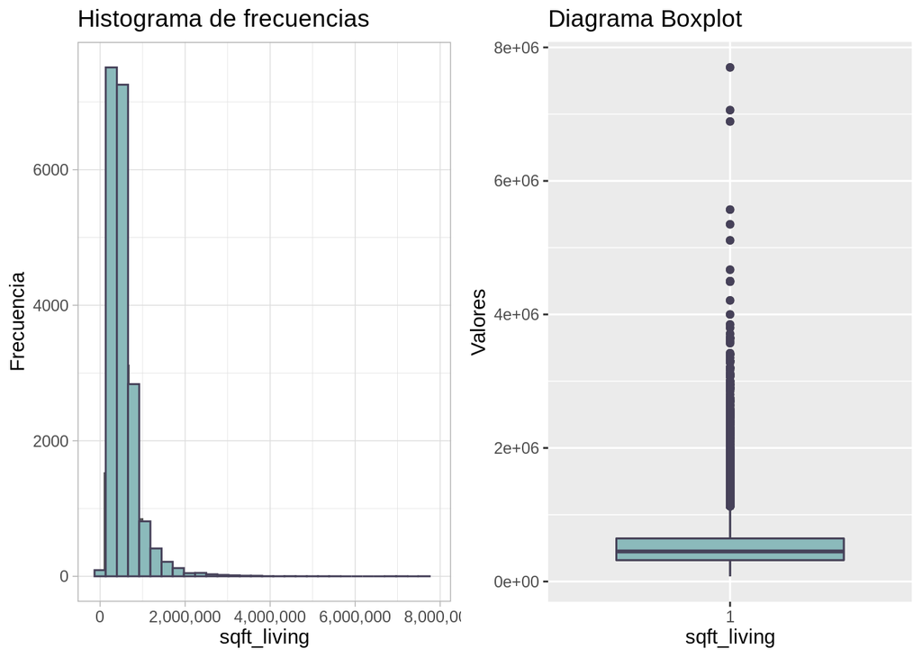

```r
# Visualización de la variable
p1 <- phist(var_price, 50, name)
p2 <- pbox(var_price, name)
grid.arrange(p1, p2, nrow=1)
```

```r
#comprobación de normalidad por Kolmogorov-Smirnov
lillie.test(var_price)
```

```
##
##  Lilliefors (Kolmogorov-Smirnov) normality test
##
## data:  var_price
## D = 0.14619, p-value < 2.2e-16
```

Tras la visualización de la variable “price” mediente el histograma de frecuencias y el diagrama de caja, se puede observar que la variable no sigue una distribución normal y contiene múltiples outliars. Se ha realizado también una comprobación mediante el test de Kolmogorov-Smirnov rechazando Ho de que la distribución es normal.

Las posibles soluciones a plantearnos para su transformación son:  
1. Transformacion logaritmico 10  
2. Raiz cuadrada  
3. Inversa 1/x

**Estudio de las variables “sqft_living” y “sqft_living15” (Superficie de la vivienda).** variable “sqft_living”: superficie de la vivienda en pies cuadrados (superficie escriturada).

```r
var_sqft = df_cuantitativas$sqft_living
name = "sqft_living"

# Descripción de la variable
describe(df_cuantitativas$sqft_living)
```

```
## df_cuantitativas$sqft_living
##        n  missing distinct     Info     Mean      Gmd      .05      .10      .25      .50      .75      .90
##    19400       39      991        1     2080      978      940     1090     1430     1910     2550     3250
##      .95
##     3760
##
## lowest :   370   380   390   410   420, highest:  9640  9890 10040 12050 13540
```

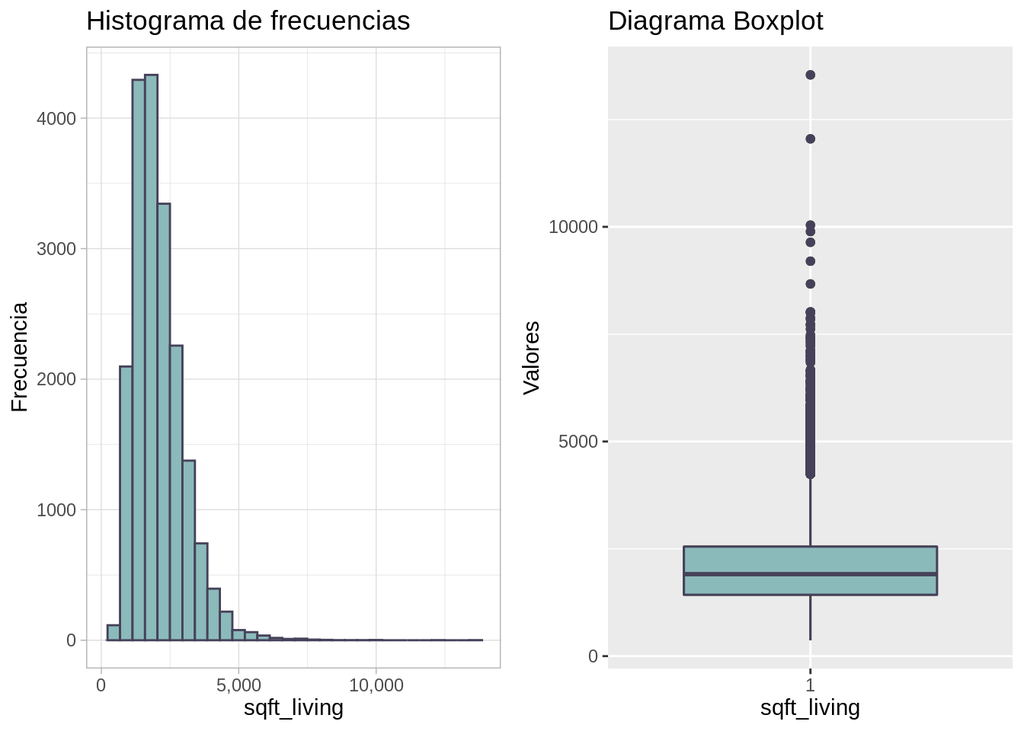

```r
# Visualización de la variable
p1 <- phist(var_sqft, 50, name)
p2 <- pbox(var_sqft, name)
grid.arrange(p1, p2, nrow=1)
```

```r
#comprobación de normalidad por Kolmogorov-Smirnov
lillie.test(var_sqft)
```

```
##
##  Lilliefors (Kolmogorov-Smirnov) normality test
##
## data:  var_sqft
## D = 0.078862, p-value < 2.2e-16
```

variable “sqft_living15”: superficie de la vivienda en pies cuadrados (superficie escriturada).

```r
var_sqft15 = df_cuantitativas$sqft_living15
name = "sqft_living15"

# Descripción de la variable
describe(df_cuantitativas$sqft_living15)
```

```
## df_cuantitativas$sqft_living15
##        n  missing distinct     Info     Mean      Gmd      .05      .10      .25      .50      .75      .90
##    19439        0      752        1     1987      744     1140     1256     1490     1840     2366     2930
##      .95
##     3291
##
## lowest :  399  460  620  670  690, highest: 5600 5610 5790 6110 6210
```

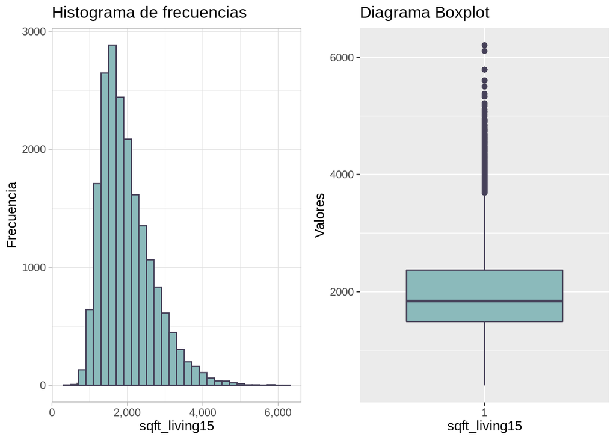

```r
# Visualización de la variable
p1 <- phist(var_sqft15, 50, name)
p2 <- pbox(var_sqft15, name)
grid.arrange(p1, p2, nrow=1)
```

```r
#comprobación de normalidad por Kolmogorov-Smirnov
lillie.test(var_sqft15)
```

```
##
##  Lilliefors (Kolmogorov-Smirnov) normality test
##
## data:  var_sqft15
## D = 0.089213, p-value < 2.2e-16
```

Tras la visualización de la variable “sqft_living” mediente el histograma de frecuencias y el diagrama de caja, se puede observar que la variable no sigue una distribución normal y contiene múltiples outliars. Se ha realizado también una comprobación mediante el test de Kolmogorov-Smirnov rechazando Ho de que la distribución es normal.

Las posibles soluciones a plantearnos para su transformación son:  
1. Transformacion logaritmico 10  
2. Raiz cuadrada  
3. Inversa 1/x

**Estudio de las variables “sqft_lot” y "sqft_lot15 (superficie de la parcela de la vivienda).** Variables “sqft_lot”: superficie de la parcela de la vivienda en pies cuadrados (superficie parcelaria).

```r
knitr::opts_chunk$set(message = FALSE)
var_lot = df_cuantitativas$sqft_lot
name = "sqft_lot"

# Descripción de la variable
describe(var_lot)
```

```
## var_lot
##        n  missing distinct     Info     Mean      Gmd      .05      .10      .25      .50      .75      .90
##    19385       54     9119        1    15149    17941     1778     3300     5043     7620    10660    21583
##      .95
##    43560
##
## lowest :     520     572     600     609     635, highest:  982998 1024068 1074218 1164794 1651359
```

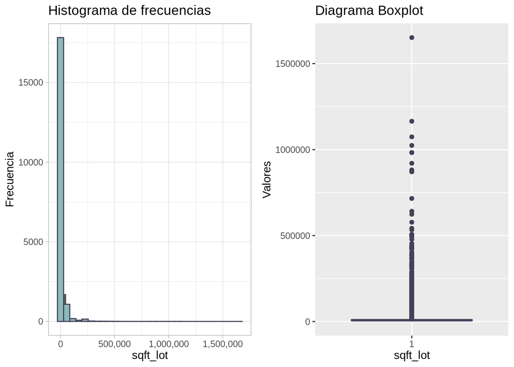

```r
# Visualización de la variable
p1 <- phist(var_lot, 50, name)
p2 <- pbox(var_lot, name)
grid.arrange(p1, p2, nrow=1)
```

```r
#comprobación de normalidad por Kolmogorov-Smirnov
lillie.test(var_lot)
```

```
##
##  Lilliefors (Kolmogorov-Smirnov) normality test
##
## data:  var_lot
## D = 0.36425, p-value < 2.2e-16
```

Variable “sqft_lot15”: superficie de la parcela en el año 2015 (admite modificaciones)

```r
var_lot15 = df_cuantitativas$sqft_lot15
name = "sqft_lot15"

# Descripción de la variable
describe(var_lot15)
```

```
## var_lot15
##        n  missing distinct     Info     Mean      Gmd      .05      .10      .25      .50      .75      .90
##    19439        0     8139        1    12880    13624     1976     3622     5100     7620    10083    17854
##      .95
##    37572
##
## lowest :    651    659    660    748    750, highest: 425581 434728 560617 858132 871200
```

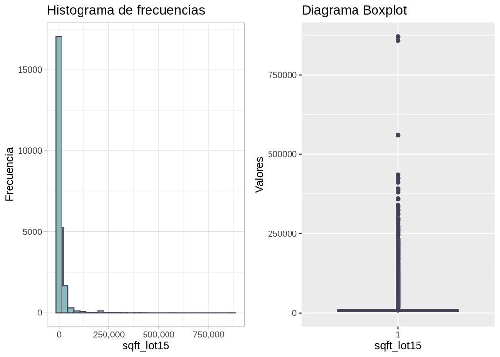

```r
# Visualización de la variable
p1 <- phist(var_lot15, 50, name)
p2 <- pbox(var_lot15, name)
grid.arrange(p1, p2, nrow=1)
```

```r
#comprobación de normalidad por Kolmogorov-Smirnov
lillie.test(var_lot15)
```

```
##
##  Lilliefors (Kolmogorov-Smirnov) normality test
##
## data:  var_lot15
## D = 0.34893, p-value < 2.2e-16
```

Dado que la gran mayoría de viviendas aparentan ser unifamiliares las variables de superficies de parcela y de vivienda suelen estar muy correlacionadas entre si. De esta manera, se puede observar como producen visualizaciones y resultados similares, rechazando en todas ellas que la distribución sea normal.

En los apartados de transformación nos plantearemos las posibles soluciones a aplicar.

**Estudio de la variable “sqft_above” (superficie de la huella de la vivienda).**

```r
var_above = df_cuantitativas$sqft_above
name = "sqft_above"

# Descripción de la variable
describe(var_above)
```

```
## var_above
##        n  missing distinct     Info     Mean      Gmd      .05      .10      .25      .50      .75      .90
##    19401       38      909        1     1788      876      850      970     1190     1560     2210     2940
##      .95
##     3390
##
## lowest :  370  380  390  410  420, highest: 7880 8020 8570 8860 9410
```

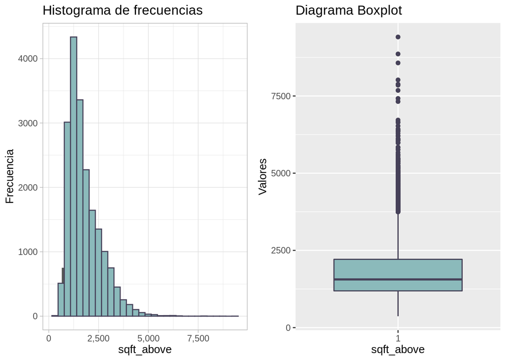

```r
# Visualización de la variable
p1 <- phist(var_above, 50, name)
p2 <- pbox(var_above, name)
grid.arrange(p1, p2, nrow=1)
```

```r
#comprobación de normalidad por Kolmogorov-Smirnov
lillie.test(var_above)
```

```
##
##  Lilliefors (Kolmogorov-Smirnov) normality test
##
## data:  var_above
## D = 0.11755, p-value < 2.2e-16
```

Al tratarse de una variable de superficie de la huella, la variable coincidirá con la superficie de la vivienda en aquellos casos en los que la vivienda tenga una planta. De esta manera “sqft_above” no puede aceptarse como una variable de distribución normal.

En los apartados de transformación nos plantearemos las posibles soluciones a aplicar.

**Estudio de la variable “sqft_basement” (superficie bajo rasante).**

```r
var_base = df_cuantitativas$sqft_basement
name = "sqft_basement"

# Descripción de la variable
describe(var_base)
```

```
## var_base
##        n  missing distinct     Info     Mean      Gmd      .05      .10      .25      .50      .75      .90
##    19399       40      298    0.778      292    422.4        0        0        0        0      560      970
##      .95
##     1190
##
## lowest :    0   10   20   40   50, highest: 3000 3480 3500 4130 4820
```

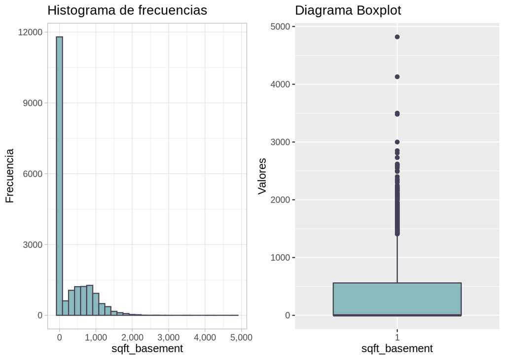

```r
# Visualización de la variable
p1 <- phist(var_base, 50, name)
p2 <- pbox(var_base, name)
grid.arrange(p1, p2, nrow=1)
```

```r
#comprobación de normalidad por Kolmogorov-Smirnov
lillie.test(df_cuantitativas$sqft_basement)
```

```
##
##  Lilliefors (Kolmogorov-Smirnov) normality test
##
## data:  df_cuantitativas$sqft_basement
## D = 0.35114, p-value < 2.2e-16
```

En esta variable se han igualado a 0 aquellos casos en los que la vivienda no tenga sótano. Por otro lado hay que contar con que en la mayoría de los casos la superficie de sótano no computa con la de vivienda, aunque si puede influir en el valor de la vivienda.

En los apartados de transformación nos plantearemos las posibles soluciones a aplicar.

**Estudio de la variable “yr_built” (año de construcción de la vivienda).**

```r
var_year = df_cuantitativas$yr_built
name = "yr_built"

# Descripción de la variable
describe(var_year)
```

```
## var_year
##        n  missing distinct     Info     Mean      Gmd      .05      .10      .25      .50      .75      .90
##    19428       11      116        1     1971    33.41     1915     1926     1951     1975     1997     2007
##      .95
##     2011
##
## lowest : 1900 1901 1902 1903 1904, highest: 2011 2012 2013 2014 2015
```

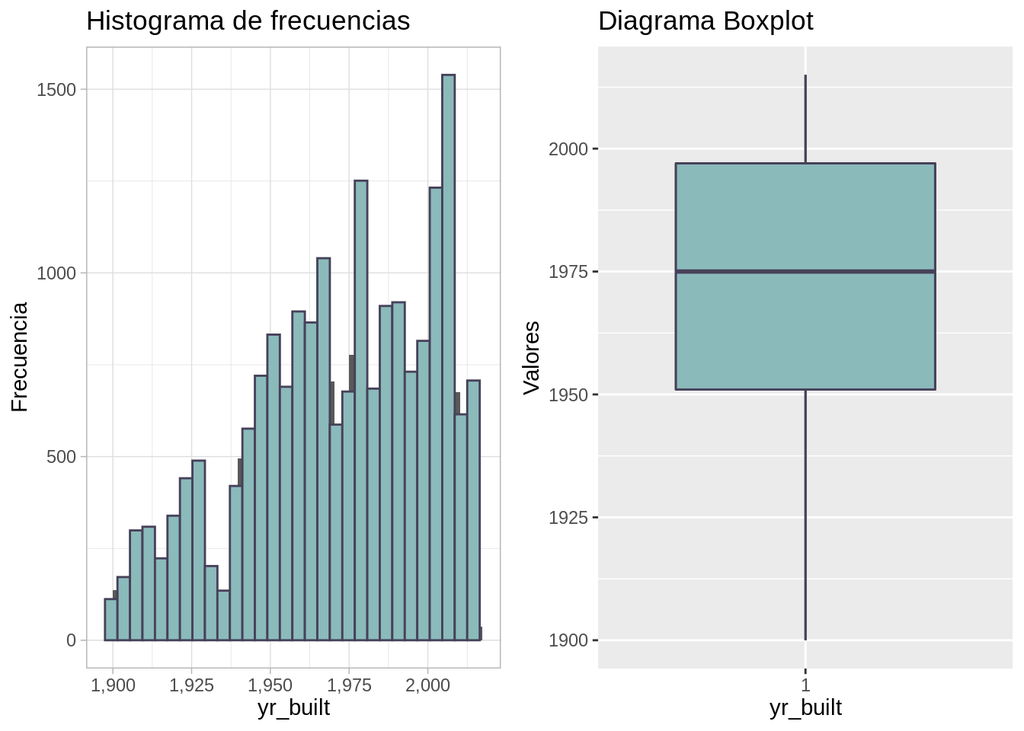

```r
# Visualización de la variable
p1 <- phist(var_year, 50, "yr_built")
p2 <- pbox(var_year, "yr_built")
grid.arrange(p1, p2, nrow=1)
```

Se puede observar que hay mayor cantidad de viviendas modernas que de antiguas en la base de datos sin seguir una distribución normal, registranto el máximo entre el año 2000 y 2010.

En los apartados de transformación nos plantearemos las posibles soluciones a aplicar.

**Estudio de la variable “yr_renovated” (año de renovación de la vivienda).**

```r
var_renove = df_cuantitativas$yr_renovated
name = "yr_renovated"

# Descripción de la variable
describe(var_renove)
```

```
## var_renove
##        n  missing distinct     Info     Mean      Gmd      .05      .10      .25      .50      .75      .90
##    19429       10       70    0.121    83.82    160.6        0        0        0        0        0        0
##      .95
##        0
##
## lowest :    0 1934 1940 1944 1945, highest: 2011 2012 2013 2014 2015
##
## Value          0  1935  1940  1945  1950  1955  1960  1965  1970  1975  1980  1985  1990  1995  2000  2005
## Frequency  18613     1     2     6     4    12    11    13    21    23    36    82    94    73   103   137
## Proportion 0.958 0.000 0.000 0.000 0.000 0.001 0.001 0.001 0.001 0.001 0.002 0.004 0.005 0.004 0.005 0.007
##
## Value       2010  2015
## Frequency     72   126
## Proportion 0.004 0.006
##
## For the frequency table, variable is rounded to the nearest 5
```

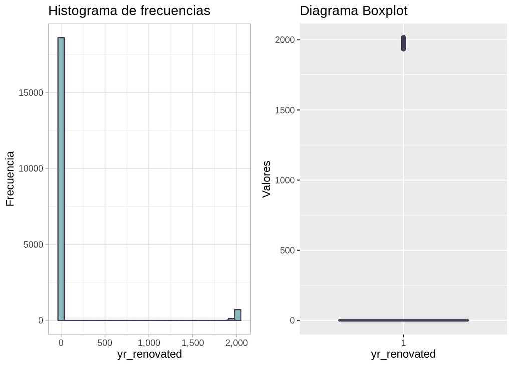

```r
# Visualización de la variable
p1 <- phist(var_renove, 25, name)
p2 <- pbox(var_renove, name)
grid.arrange(p1, p2, nrow=1)
```

```r
#comprobación de normalidad por Kolmogorov-Smirnov
lillie.test(var_renove)
```

```
##
##  Lilliefors (Kolmogorov-Smirnov) normality test
##
## data:  var_renove
## D = 0.54092, p-value < 2.2e-16
```

El problema que observamos en esta variable es que aquellas viviendas que no han sido renovadas se han igualado a 0, no permitiendo visualizar la variable correctamente.

### B. Analisis univariante cualitativo

```r
#Obtención de variables cuantitativas
df_cualitativas = price_tplusc %>% select(2, 4, 5, 8:12, 17)

data.frame(variable = names(df_cualitativas),
           classe = sapply(df_cualitativas, typeof),
           first_values = sapply(df_cualitativas, function(x) paste0(head(x),  collapse = ", ")),
           row.names = NULL) %>% kable() %>% kable_styling()
```

| variable | classe | first_values |
| --- | --- | --- |
| date | integer | 10/13/2014, 12/09/2014, 2/25/2015, 12/09/2014, 2/18/2015, 05/12/2014 |
| bedrooms | integer | 3, 3, 2, 4, 3, 4 |
| bathrooms | double | 1, 2.25, 1, 3, 2, 4.5 |
| floors | double | 1, 2, 1, 1, 1, 1 |
| waterfront | integer | 0, 0, 0, 0, NA, 0 |
| view | integer | 0, 0, 0, 0, 0, 0 |
| condition | integer | 3, 3, 3, 5, 3, 3 |
| grade | integer | 7, 7, 6, 7, 8, 11 |
| zipcode | integer | 98178, 98125, 98028, 98136, 98074, 98053 |

**Estudio de la variable “date” (fecha de venta de la vivienda):** Dado que el objetivo de la práctica es poder predecir el precio de la vivienda, sería interesante para nuestro modelo separar esta variable en mes y año ya que el precio de venta se puede ver influido por la estación y por el año en el que se realizó la venta.

```r
dates = data.frame(date = as.Date(df_cualitativas$date,"%m/%d/%Y"))
df_cualitativas$dates_m = format(dates,"%m")
df_cualitativas$dates_y = format(dates,"%Y")

# Límites del campo date
dates %>% summarise(min = min(date), max = max(date))
```

```
##          min        max
## 1 2014-05-02 2015-05-27
```

```r
# Tablas de frecuencias en función al mes y al año
table(df_cualitativas$dates_y) %>% kable(., col.names = c('Años', 'Frecuencia'))
```

| Años | Frecuencia |
| --- | --- |
| 2014 | 13146 |
| 2015 | 6293 |

```r
table(df_cualitativas$dates_m) %>% kable(., col.names = c('Meses', 'Frecuencia'))
```

| Meses | Frecuencia |
| --- | --- |
| 01 | 878 |
| 02 | 1107 |
| 03 | 1706 |
| 04 | 2015 |
| 05 | 2168 |
| 06 | 1961 |
| 07 | 1995 |
| 08 | 1733 |
| 09 | 1612 |
| 10 | 1676 |
| 11 | 1269 |
| 12 | 1319 |

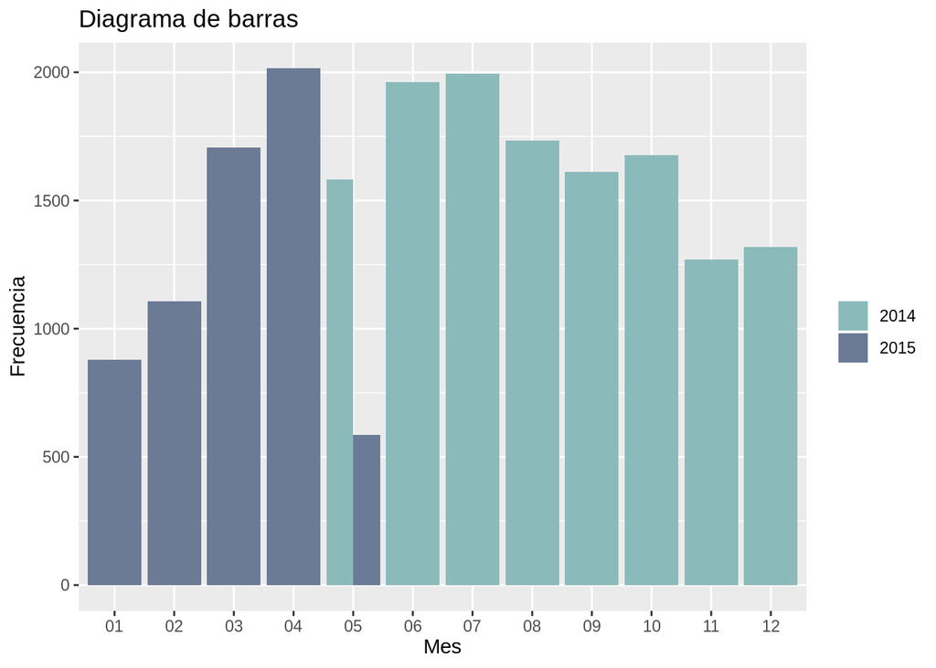

```r
# Diagrama de barras con los meses del año y el número de viviendas vendidas
p_barras2(df_cualitativas, df_cualitativas$dates_m, df_cualitativas$dates_y, xlab = 'Mes')
```

```r
var_rooms = df_cualitativas$bedrooms %>% round(., digits=0)
name = "bedrooms"

# Tablas de frecuencias en función al mes y al año
table(var_rooms) %>% kable(., col.names = c(name, 'Frecuencia'))
```

| bedrooms | Frecuencia |
| --- | --- |
| 1 | 184 |
| 2 | 2481 |
| 3 | 8806 |
| 4 | 6178 |
| 5 | 1438 |
| 6 | 246 |
| 7 | 35 |
| 8 | 12 |
| 9 | 5 |
| 10 | 2 |
| 11 | 1 |

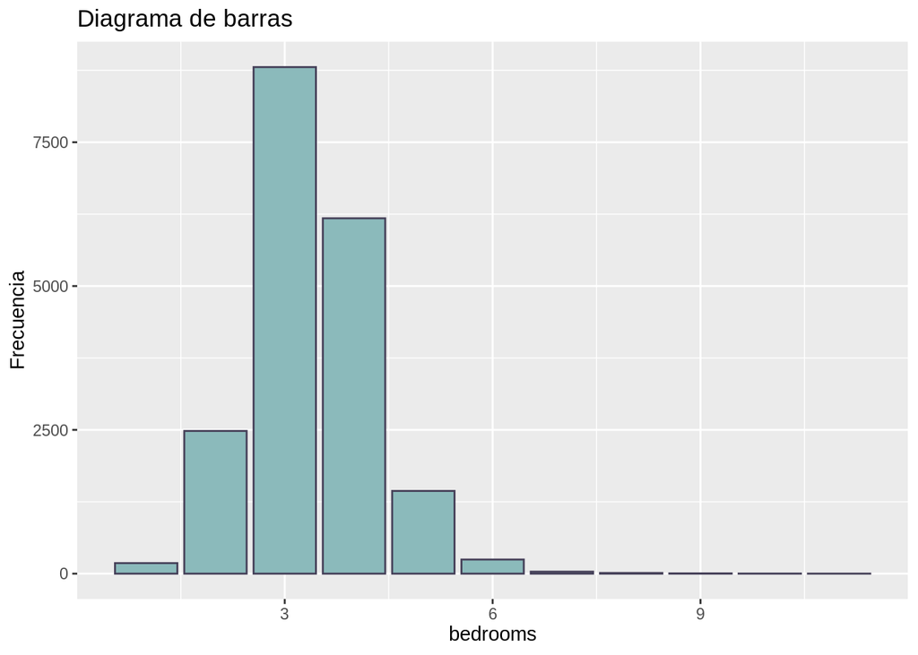

```r
# Diagrama de barras con los meses del año y el número de viviendas vendidas
p_barras(df_cualitativas, var_rooms, xlab = name)
```

La frecuencia máxima de habitaciones por vivienda se localiza en 3 habitaciones, probablemente deban categorizarse debido a que la distribución no es normal y contiene multiples outliers que la desequilibran.

**Estudio de la variable “bathrooms” (Número de baños/aseos por vivienda):** Al igual que en el caso anterior la variable bathrooms es decimal por lo que la redondearemos para simplificar su representación.

```r
var_bathrooms = df_cualitativas$bathrooms %>%  round(., digits = 0)
name = "bathrooms"

# Tablas de frecuencias en función al mes y al año
table(var_bathrooms) %>% kable(., col.names = c(name, 'Frecuencia'))
```

| bathrooms | Frecuencia |
| --- | --- |
| 0 | 3 |
| 1 | 3529 |
| 2 | 12433 |
| 3 | 2266 |
| 4 | 1087 |
| 5 | 54 |
| 6 | 23 |
| 7 | 2 |
| 8 | 4 |

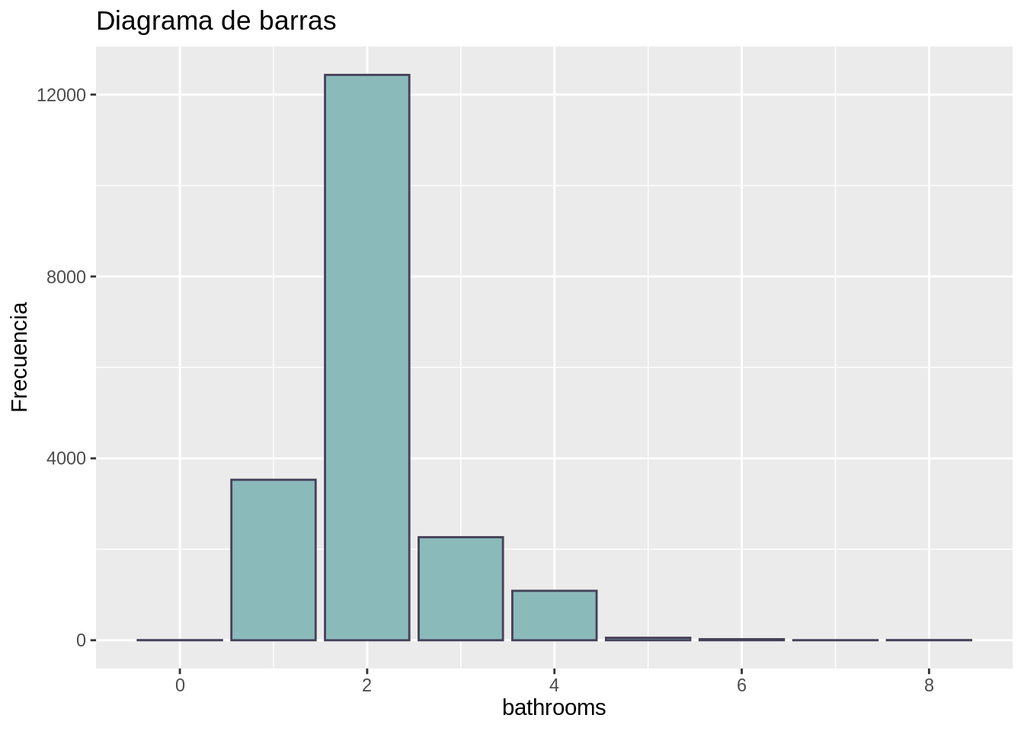

```r
# Diagrama de barras con los meses del año y el número de viviendas vendidas
p_barras(df_cualitativas, var_bathrooms, xlab = name)
```

La variable “bathrooms” sigue una distribución muy similar a la de la variable “bedrooms” por lo que aplicaremos las mismas soluciones.

**Estudio de la variable “floors” (Número de plantas por vivienda):** Como en los casos anteriores la variable “floors” es decimal, pero a diferencia de los anteriores solo encontramos decimales con saltos de 0.5 por lo que redondearlos hacia arriba o hacia abajo todos podría perjudicarnos posteriormente en el modelo. De esta manera mantendremos los datos como en el origen para su correcta visualización.

```r
var_floors = df_cualitativas$floors
name = "floors"

# Tablas de frecuencias en función al mes y al año
table(var_floors) %>% kable(., col.names = c(name, 'Frecuencia'))
```

| floors | Frecuencia |
| --- | --- |
| 1 | 9580 |
| 1.5 | 1721 |
| 2 | 7412 |
| 2.5 | 136 |
| 3 | 562 |
| 3.5 | 6 |

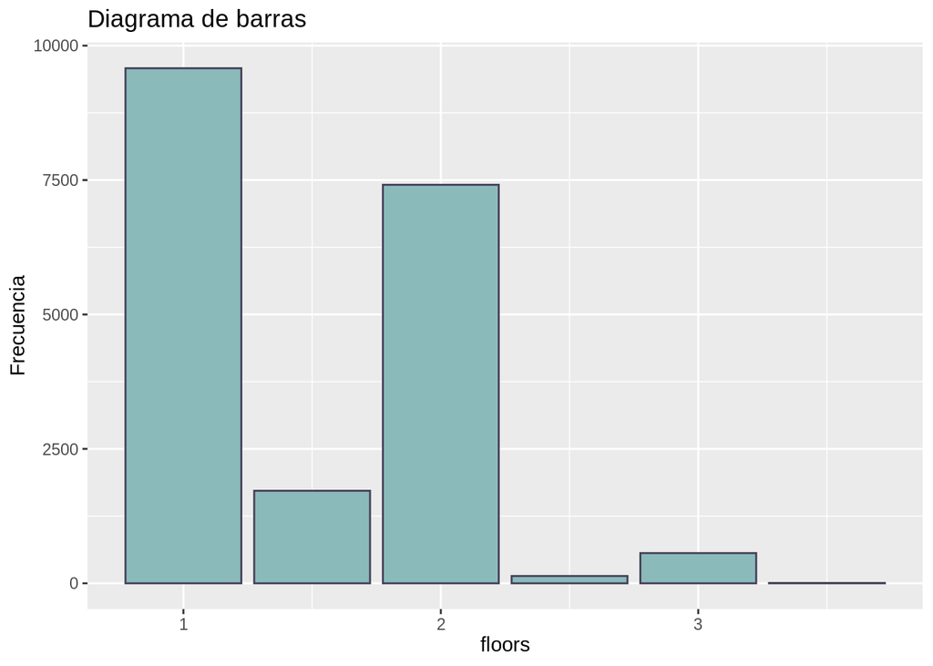

```r
# Diagrama de barras con los meses del año y el número de viviendas vendidas
p_barras(df_cualitativas, var_floors, xlab = name)
```

Se puede observar que el número de valores decimales es reducido en comparación con el resto, pero creemos que deberían mantenerse sin redondear.

**Estudio de la variable “waterfront” (viviendas frente a grandes masas de agua):**

```r
var_waterfront = df_cualitativas$waterfront
name = "waterfront"

# Tablas de frecuencias en función al mes y al año
table(var_waterfront) %>% kable(., col.names = c(name, 'Frecuencia'))
```

| waterfront | Frecuencia |
| --- | --- |
| 0 | 19267 |
| 1 | 144 |

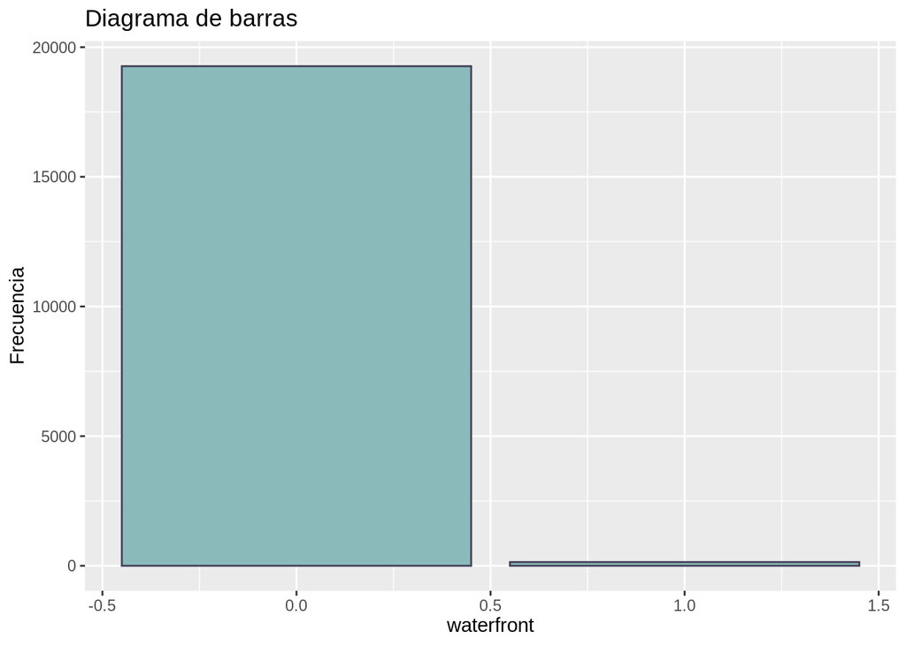

```r
# Diagrama de barras con los meses del año y el número de viviendas vendidas
p_barras(df_cualitativas, var_waterfront, xlab = name)
```

Esta variable es de tipo dummy por lo que no necesitaría modificación alguna salvo por la imputación de datos faltantes. Se puede observar que tan solo el 1% de las viviendas de la base de datos están ubicadas frente a grandes masas de agua.

**Estudio de la variable “view” (número de visitas que ha recibido la vivienda):**

```r
var_view = df_cualitativas$view
name = "waterfront"

# Tablas de frecuencias en función al mes y al año
table(var_view) %>% kable(., col.names = c(name, 'Frecuencia'))
```

[output not shown]

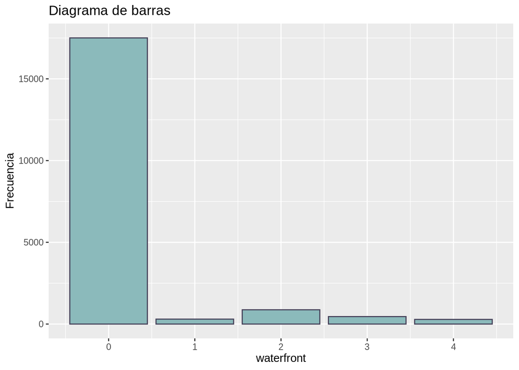

```r
# Diagrama de barras con los meses del año y el número de viviendas vendidas
p_barras(df_cualitativas, var_view, xlab = name)
```

Dado que la mayoría de las viviendas no han recibido visitas, inicialmente no parece una variable que pueda afectar mucho al precio de la vivienda por lo que podría ser deshechada tras el análisis multivariante.

**Estudio de la variable “condition” (estado de la vivienda del 1 al 5):**

```r
var_condition = df_cualitativas$condition
name = "condition"

# Tablas de frecuencias en función al mes y al año
table(var_condition) %>% kable(., col.names = c(name, 'Frecuencia'))
```

| condition | Frecuencia |
| --- | --- |
| 1 | 26 |
| 2 | 151 |
| 3 | 12589 |
| 4 | 5111 |
| 5 | 1535 |

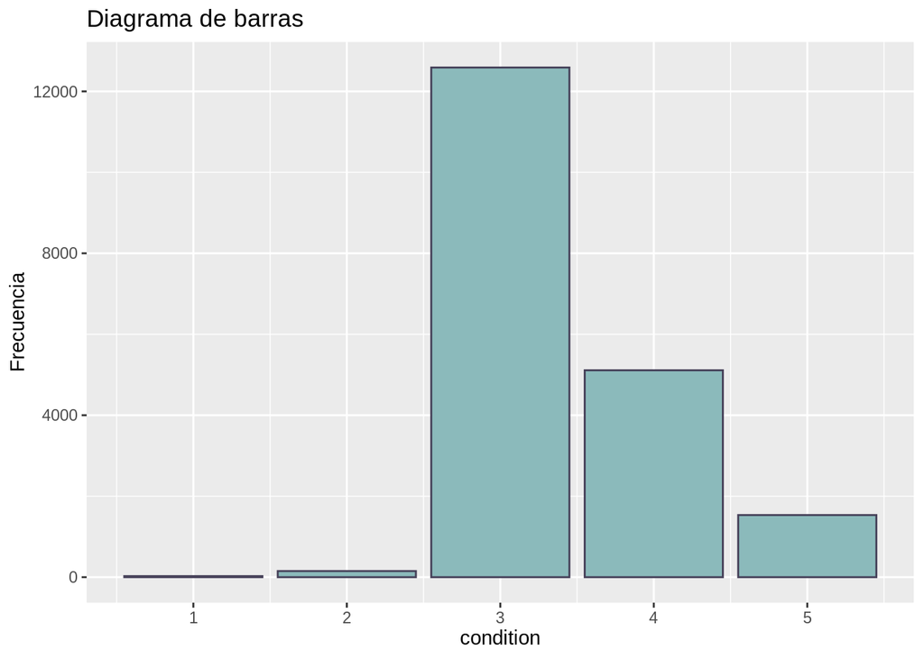

```r
# Diagrama de barras con los meses del año y el número de viviendas vendidas
p_barras(df_cualitativas, var_condition, xlab = name)
```

La variable “condition” determina el estado de la vivienda clasificándola en una puntuación del 1 al 5, dado que la mayor parte de las viviendas se distribuyen en los puntos 3 y 4 podríamos simplificarla mediante una variable dummy.

**Estudio de la variable “grade” (nota general de la vivienda del 1 al 13):**

```r
var_grade = df_cualitativas$grade
name = "grade"

# Tablas de frecuencias en función al mes y al año
table(var_grade) %>% kable(., col.names = c(name, 'Frecuencia'))
```

| grade | Frecuencia |
| --- | --- |
| 10 | 1016 |
| 11 | 349 |
| 12 | 83 |
| 13 | 11 |
| 3 | 1 |
| 4 | 26 |
| 5 | 219 |
| 6 | 1849 |
| 7 | 8049 |
| 8 | 5463 |
| 9 | 2351 |
| s | 1 |

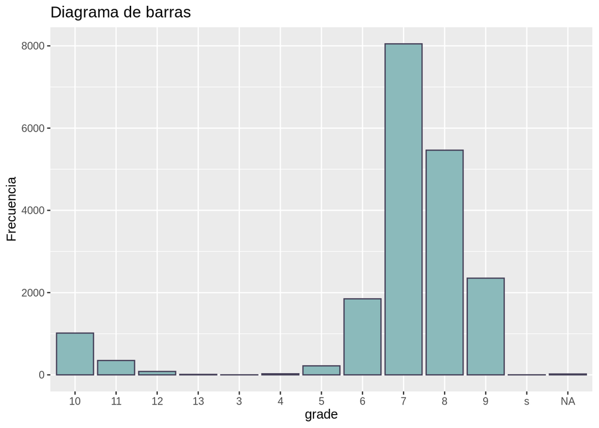

```r
# Diagrama de barras con los meses del año y el número de viviendas vendidas
p_barras(df_cualitativas, var_grade, xlab = name)
```

Al igual que la anterior, la variable “grade” determina la nota general de la vivienda propuesta por la zona, dado que la mayor parte de las viviendas se distribuyen entre los valores del 6 al 10 podríamos simplificarla mediante una variable dummy.

```r
var_zipcode = df_cualitativas$view
name = "zipcode"

# Tablas de frecuencias en función al mes y al año
table(var_zipcode) %>% kable(., col.names = c(name, 'Frecuencia'))
```

[output not shown]

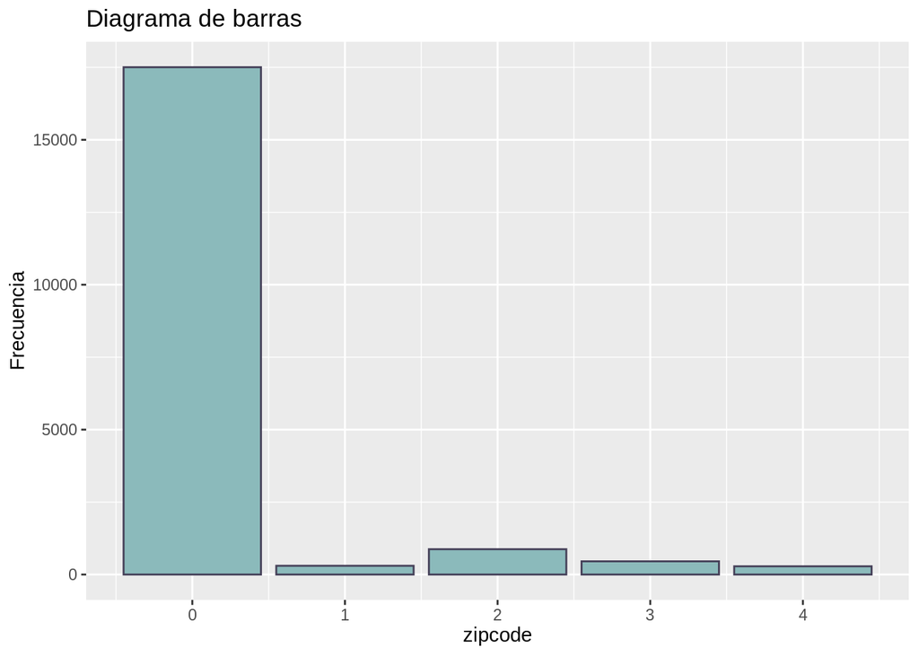

```r
# Diagrama de barras con los meses del año y el número de viviendas vendidas
p_barras(df_cualitativas, var_zipcode, xlab = name)
```

### c. Análisis multivariante cuantitativo

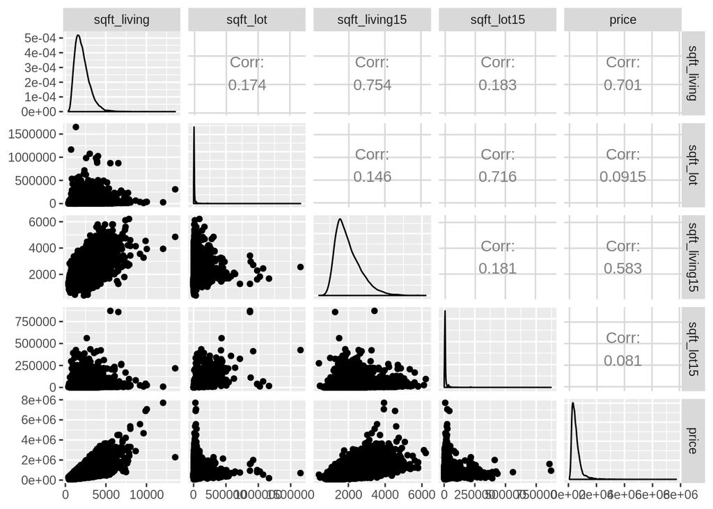

```r
numeric_cols <- c("sqft_living", "sqft_lot", "sqft_living15", "sqft_lot15", "price")

df_cuantitativas %>% select(numeric_cols) %>%
  na.omit() %>%
  ggpairs(columns=1:5)
```

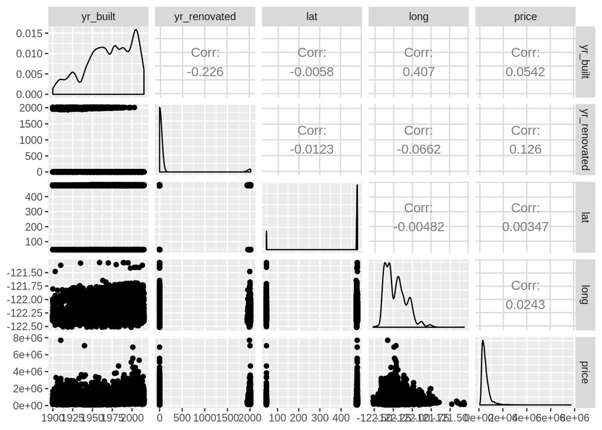

```r
numeric_cols2 <- c("yr_built", "yr_renovated", 'lat', 'long', "price")

df_cuantitativas %>% select(numeric_cols2) %>%
  na.omit() %>%
  ggpairs(columns=1:5)
```

### c. Análisis multivariante cualitativo

**Estudio de la variable “bedrooms” (número de habitaciones por vivienda):**

```r
old = "bedrooms"
new = "cat_bedrooms"

#categorizamos la variable y mostramos su tabla de frecuencias
price_tplusc[[new]] = cut2(price_tplusc[[old]], g=4)
table(price_tplusc[[new]])
```

```
##
## [1, 4)      4 [5,11]
##  11471   6178   1739
```

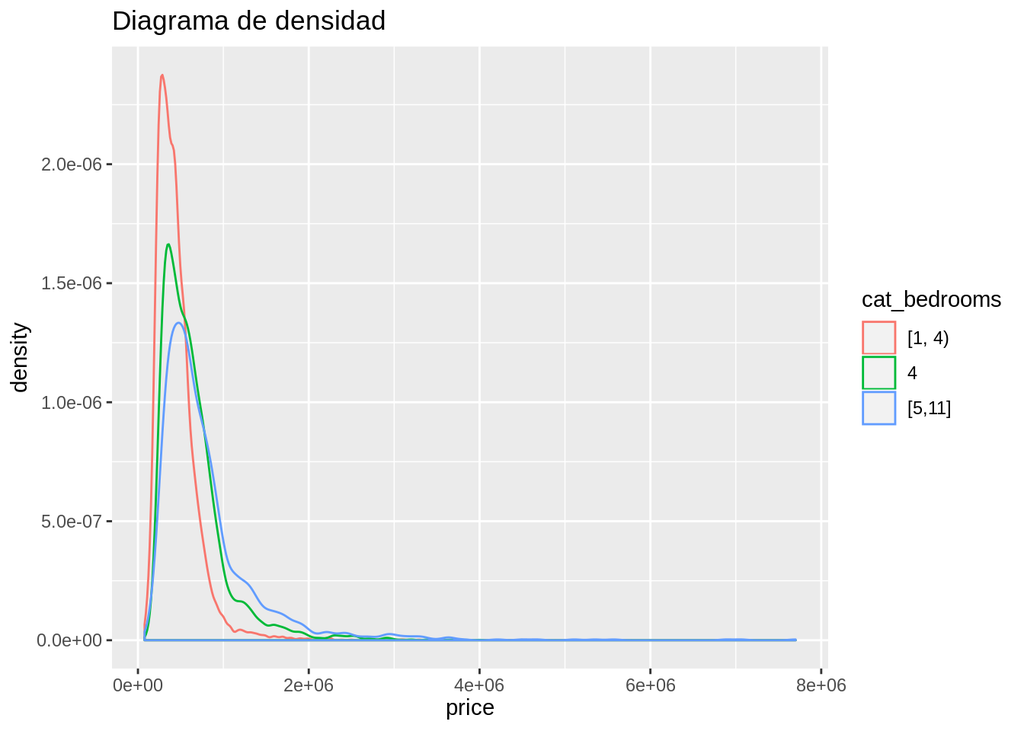

```r
#visualización de los datos categorizados con respecto a la variable "price"
p_densidad(price_tplusc, new)
```

**Estudio de la variable “bathrooms” (número de baños/aseos por vivienda):**

```r
old = "bathrooms"
new = "cat_bathrooms"

#categorizamos la variable y mostramos su tabla de frecuencias
price_tplusc[[new]] = cut2(price_tplusc[[old]], g=3)
table(price_tplusc[[new]])
```

```
##
## [0.50,2.00) [2.00,2.75) [2.75,8.00]
##        7554        8411        3436
```

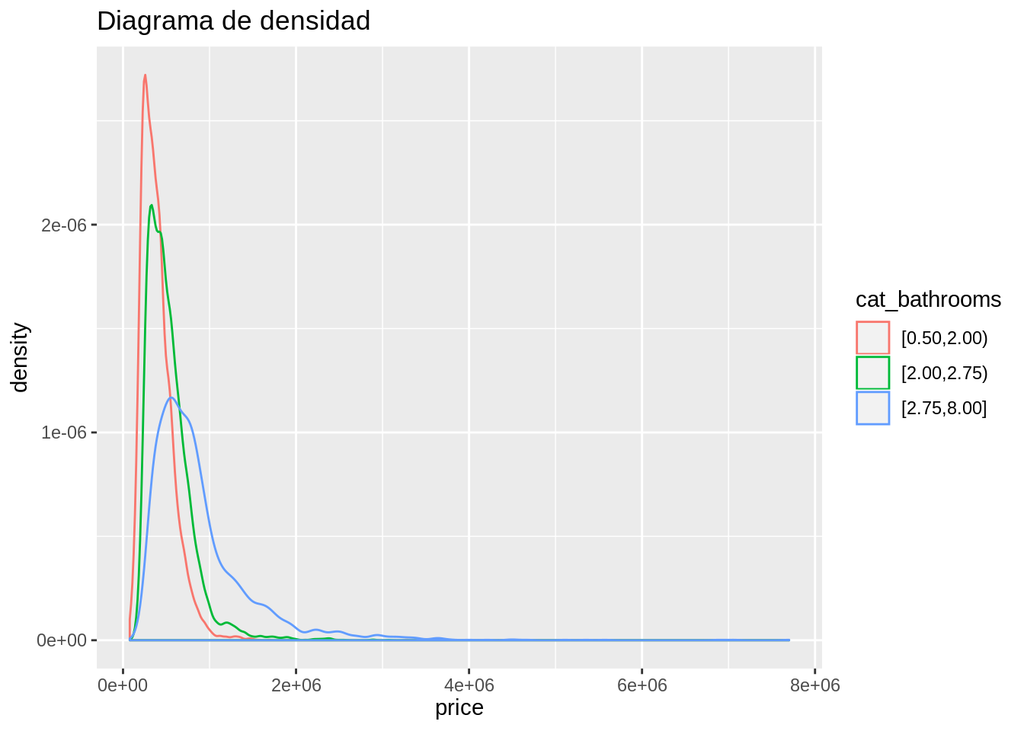

```r
#visualización de los datos categorizados con respecto a la variable "price"
p_densidad(price_tplusc, new)
```

**Estudio de la variable “floors” (número de plantas por vivienda):**

```r
old = "floors"
new = "cat_floors"

#categorizamos la variable y mostramos su tabla de frecuencias
price_tplusc[[new]] = cut2(price_tplusc[[old]], g=3)
table(price_tplusc[[new]])
```

```
##
##       1.0 [1.5,2.5) [2.5,3.5]
##      9580      9133       704
```

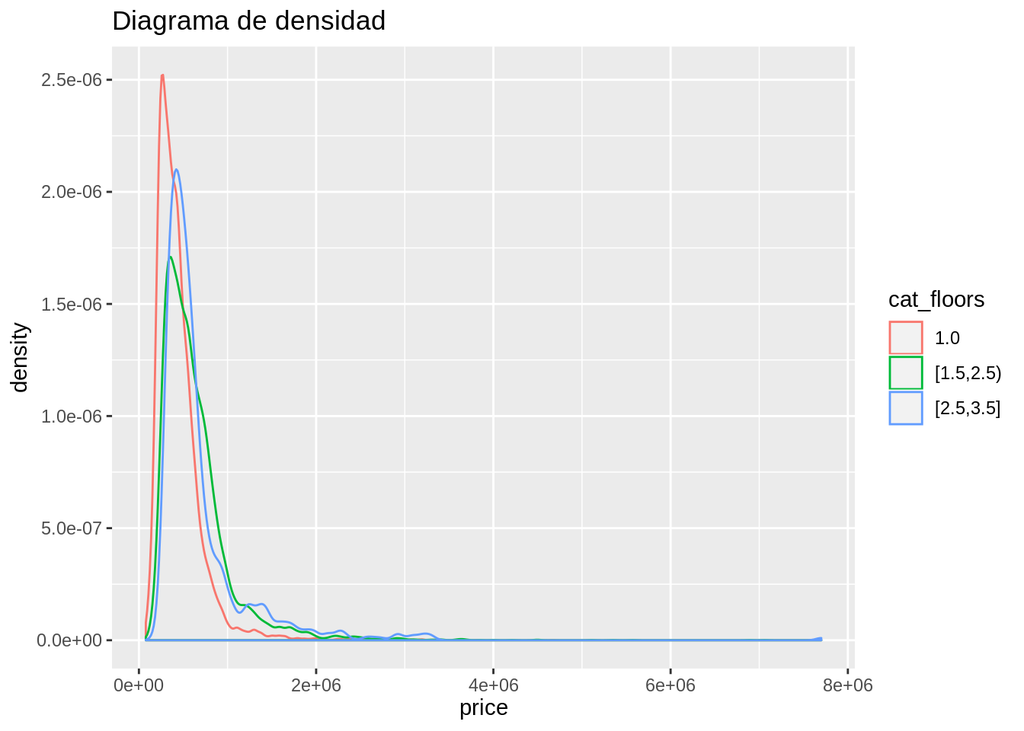

```r
#visualización de los datos categorizados con respecto a la variable "price"
p_densidad(price_tplusc, new)
```

```r
name = "waterfront"

#mostramos su tabla de frecuencias
table(price_tplusc[[name]])
```

```
##
##     0     1
## 19267   144
```

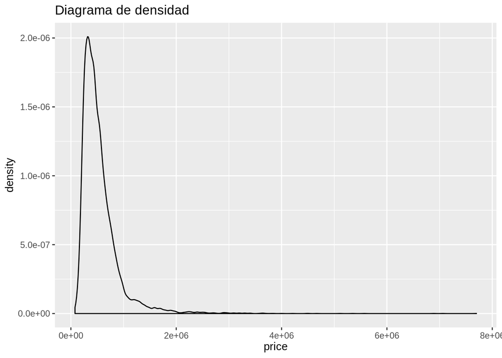

```r
#visualización de los datos categorizados con respecto a la variable "price"
p_densidad(price_tplusc, name)
```

```r
old = "view"
new = "cat_view"

#categorizamos la variable y mostramos su tabla de frecuencias
price_tplusc[[new]] = cut2(price_tplusc[[old]], g=3)
table(price_tplusc[[new]])
```

```
##
##     0 [1,4]
## 17505  1917
```

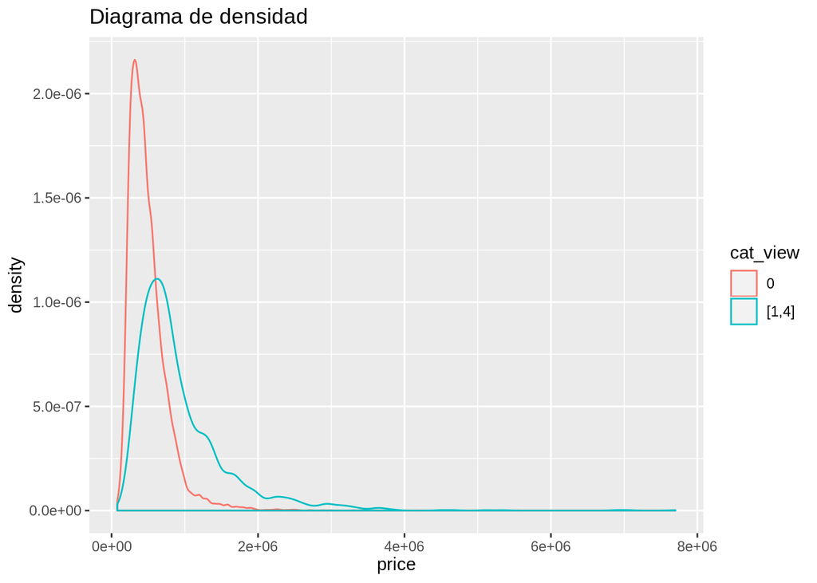

```r
#visualización de los datos categorizados con respecto a la variable "price"
p_densidad(price_tplusc, new)
```

```r
old = "condition"
new = "cat_condition"

#categorizamos la variable y mostramos su tabla de frecuencias
price_tplusc[[new]] = cut2(price_tplusc[[old]], g=3)
table(price_tplusc[[new]])
```

```
##
## [1,4)     4     5
## 12766  5111  1535
```

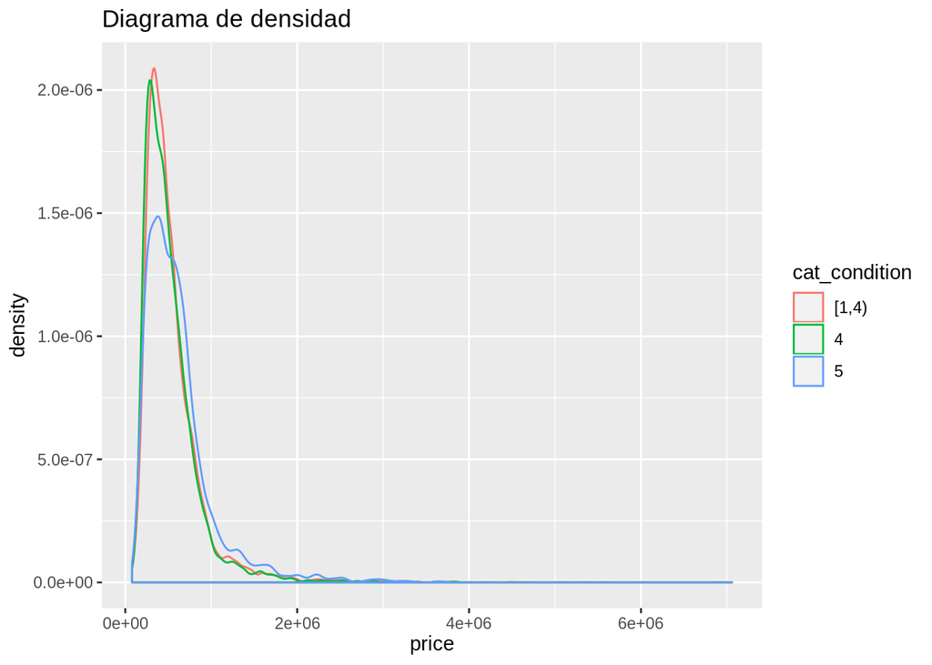

```r
#visualización de los datos categorizados con respecto a la variable "price"
p_densidad(price_tplusc, new)
```

```r
old = "grade"
new = "cat_grade"

#corrección reemplazando el string s por un "NA"
table(price_tplusc[[old]])
```

```
##
##   10   11   12   13    3    4    5    6    7    8    9    s
## 1016  349   83   11    1   26  219 1849 8049 5463 2351    1
```

```r
price_tplusc[[old]][price_tplusc[[old]] == "s"] <- NA
price_tplusc[[old]] = as.numeric(price_tplusc[[old]])
table(price_tplusc[[old]])
```

```
##
##    1    2    3    4    5    6    7    8    9   10   11
## 1016  349   83   11    1   26  219 1849 8049 5463 2351
```

```r
#categorizamos la variable y mostramos su tabla de frecuencias
price_tplusc[[new]] = cut2(price_tplusc[[old]], g=4)
table(price_tplusc[[new]])
```

```
##
## [ 1,10)      10      11
##   11603    5463    2351
```

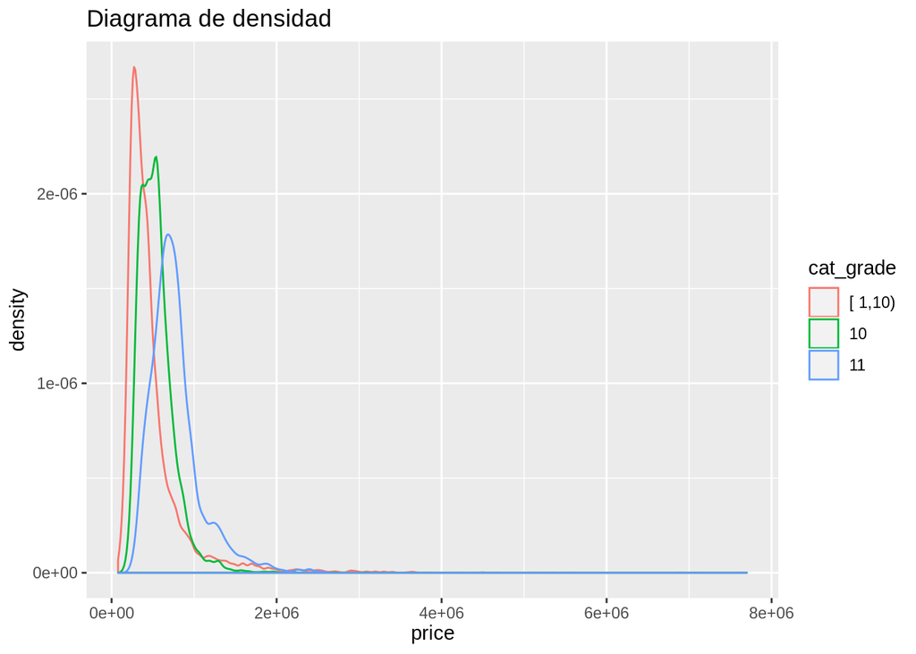

```r
#visualización de los datos categorizados con respecto a la variable "price"
p_densidad(price_tplusc, new)
```

**Estudio de la variable “zipcode” (código postal):**

```r
old = "zipcode"
new = "cat_zipcode"

#categorizamos la variable y mostramos su tabla de frecuencias
price_tplusc[[new]] = cut2(price_tplusc[[old]], g=3)
table(price_tplusc[[new]])
```

```
##
## [98001,98042) [98042,98112) [98112,98199]
##          6503          6525          6411
```

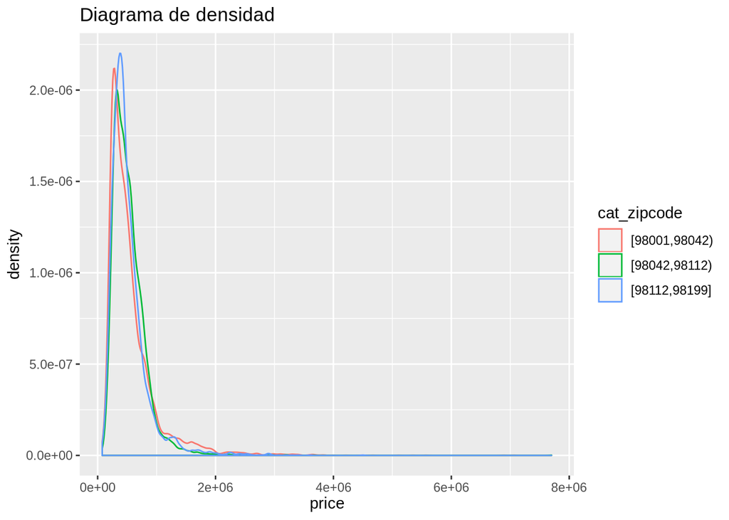

```r
#visualización de los datos categorizados con respecto a la variable "price"
p_densidad(price_tplusc, new)
```

## 04 Detección, tratamiento e imputación de datos faltantes

### Análisis previo

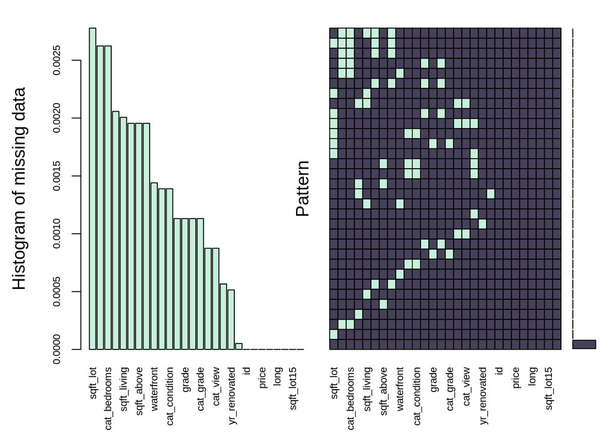

```
##
##  Variables sorted by number of missings:
##       Variable        Count
##       sqft_lot 2.777921e-03
##       bedrooms 2.623592e-03
##   cat_bedrooms 2.623592e-03
##  sqft_basement 2.057719e-03
##    sqft_living 2.006276e-03
##      bathrooms 1.954833e-03
##     sqft_above 1.954833e-03
##  cat_bathrooms 1.954833e-03
##     waterfront 1.440403e-03
##      condition 1.388960e-03
##  cat_condition 1.388960e-03
##         floors 1.131745e-03
##          grade 1.131745e-03
##     cat_floors 1.131745e-03
##      cat_grade 1.131745e-03
##           view 8.745306e-04
##       cat_view 8.745306e-04
##       yr_built 5.658727e-04
##   yr_renovated 5.144298e-04
##            lat 5.144298e-05
##             id 0.000000e+00
##           date 0.000000e+00
##          price 0.000000e+00
##        zipcode 0.000000e+00
##           long 0.000000e+00
##  sqft_living15 0.000000e+00
##     sqft_lot15 0.000000e+00
##    cat_zipcode 0.000000e+00
```

```r
aggr_plot <- aggr(price_tplusc, col=c('#464159','#c7f0db'), numbers=TRUE, sortVars=TRUE,
                  labels=names(price_tplusc), cex.axis=.7, gap=1,
                  ylab=c("Histogram of missing data","Pattern"))
```